# Introduction to R and RStudio

## Functions

We can use pre-built computation methods called “functions” for other operations. In fact, we’ve already seen and used one - the `print()` function.

Functions have the following format, where the *argument* is the information we are providing to the function for it to run.

```r
function_name(argument)
```

To learn about functions, we’ll examine one called `log()` first.

To know what a function does and how to use it, use the question mark which will reveal documentation in the **help pane**: `?log`

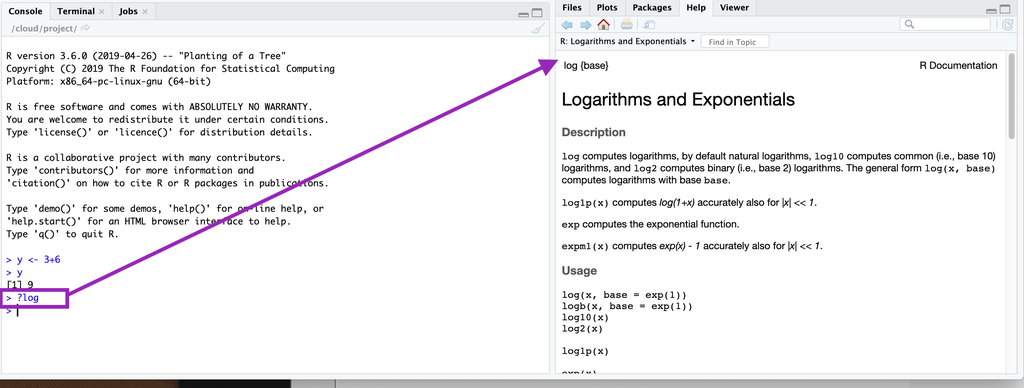

The documentation tells use that `log()` is derived from `{base}`, meaning it is a function that is part of base R. It provides a brief description of what the function does and shows several examples of to how use it.

In particular, documentation tells about how what argument(s) to provide: + The first *required* argument is the value we’d like to take the log of, by default its *natural log* + The second *optional* argument can specify a different base rather than the default `e`.

Functions also *return* values for us to use. In the case of `log()`, the returned value is the log’d value the function computed.

#### EXERCISE SET THREE

Perform the following computations using functions. Try to use *variables* while you code!

1. What is the natural log of 75?
2. What is the logarithm of 100 in base 7?
3. What is the square root of 56? (Hint: look up and apply the function `sqrt()` for this)
4. What is the log of the square root of 341? (Hint: You can do this in *one line* of code by *nesting* your functions. Play around with it!)

## Working with variables

### Variable Types

Now that you have a general sense of R usage, let’s learn about the different types of variables. We have already seen “numeric” types above using numbers, but there are more than just numbers out there. Here are some of the most important types we’ll need to know:

| Variable Type | Definition | Examples | Coersion |
| --- | --- | --- | --- |
| `numeric` | Any number value | `5` `7.5` `-1` `pi` (This is a *constant variable* defined in R as 3.1415…) | `as.numeric()` |
| `integer` | Any *whole* number value (no decimals) | `5` `-100` | `as.integer()` |
| `character` | Any collection of characters defined within *quotation marks*. Also known as a “string”. | `"a"` (a single letter) `"stringofletters"` (a whole bunch of characters put together as one) `"string of letters and spaces"` `"5"` `'single quotes are also good'` | `as.character()` |
| `logical` | A value of `TRUE`, `FALSE`, or `NA` | `TRUE` `FALSE` `NA` (not defined) | `as.logical()` |
| `factor` | A special type of variable that denotes specific CATEGORIES of a categorical variable | (stay tuned..) | `as.factor()` |

Variable types in R are what is known as “weakly typed”, meaning when possible, you can *coerce* (convert) one type to another.

For example, we can coerce an integer to be a numeric or a character:

```r
## Define an integer
x <- as.integer(15)
### The function `class()` will tell us the variable's type
class(x)
```

```
## [1] "integer"
```

```r
## Let's coerce it
x <- as.numeric(x)
class(x)
```

```
## [1] "numeric"
```

```r
x <- as.character(x)
class(x)
```

```
## [1] "character"
```

```r
print(x) ## See it now has quotes around it? It's now a character and will behave as such
```

```
## [1] "15"
```

```r
## aka, we can't add characters! even though "15" looks like a number, it's not
x + 4
```

```
## Error in x + 4: non-numeric argument to binary operator
```

```r
# we can always coerce on the fly; this does NOT redefine x though!!
as.numeric(x) + 4
```

```
## [1] 19
```

```r
x + 4
```

```
## Error in x + 4: non-numeric argument to binary operator
```

But we can’t coerce everything:

```r
## Define an integer
x <- "look at my character variable"
class(x)
```

```
## [1] "character"
```

```r
## failed coersion. there is no natural way for a sentence to be numbers
## R decided the new value is undefined: NA
x <- as.numeric(x)
print(x)
```

```
## [1] NA
```

### Logical variables and operators

One of the most important variable types are *logical variables* (known as “boolean” in many other languages). They help us to compare different quantities and there is a special set of operators for performing comparisons that *return logical values*:

| Operator | What it does |
| --- | --- |
| `==` | Tests if two quantities are EQUAL. **DOUBLE EQUALS SIGN IS SO IMPORTANT. DOUBLE. ~NOT SINGLE~** |
| `>` and `<` | Tests if one quantity is greater than or less than another |
| `>=` and `<=` | Tests if one quantity is *greater than or equal to* or *less than or equal to* another |
| `!` | Negates an operation |

Let’s examine their usage:

```r
5 == 5
```

```
## [1] TRUE
```

```r
7 >= 9
```

```
## [1] FALSE
```

```r
4 < 8
```

```
## [1] TRUE
```

```r
!(4 > 8)  ## 4 is not greater than 8. Parenthesis part is FALSE, but the `!` changes it to TRUE
```

```
## [1] TRUE
```

```r
## Your most common mistake: Using a single equals sign to compare values.
## R says you can't define a variable called 4 and make it equal 3. 4 is already a thing. It's 4.
4 = 3
```

```
## Error in 4 = 3: invalid (do_set) left-hand side to assignment
```

#### EXERCISE SET FOUR

Solve the questions below using logical operators. Each answer should end up as `TRUE` or `FALSE`, as determined by R - not by you!

1. Is 134 less than 3?
2. Is the number 150 positive or negative? (Hint: compare it to 0)
3. Is the natural log of 134 less than 3?
4. Is the square root of 81 greater than the cube root of 125? (Hint: Define two variables and use a logical operator to compare them to one another)
5. Define a character variable consisting of your name, e.g. mine is `name <- "Stephanie"`. Use a logical operator to determine if the *number of characters* in this overall variable is equal to 7. (Hint: To determine the number of characters, use the `nchar()` function. Look it up with `?nchar` if you need help using it!)

### Arrays/vectors

You will have noticed that all your computations tend to pop up with a `[1]` preceding them in R’s output. This is because, in fact, all (ok mostly all) variables are *by default* **arrays** aka vectors, and our answers are the first (in these cases only) value in the array. As arrays gets longer, new index indicators will appear at the start of new lines. **See [here](https://r4ds.had.co.nz/vectors.html) for a deeper dive into array structures.**

```r
## This is actually an array that has one item in it.
x <- 7

## The length() functions tells us how long an array is:
length(x)
```

```
## [1] 1
```

```r
## In fact, a single STRING has a length of ONE!! Compare the new function `length()` to `nchar()`
name <- "Stephanie"
nchar(name)
```

```
## [1] 9
```

```r
length(name)
```

```
## [1] 1
```

We can define arrays with the function `c()`, which stands for “combine”. This function takes a comma-separated set of values to place in the array, and returns the array itself:

```r
my_numeric_array <- c(1,1,2,3,5,8,13,21)
length(my_numeric_array)
```

```
## [1] 8
```

```r
my_mixedtype_array <- c("one", "one", "two", 3, 5, 8, 13, "twenty one")
length(my_mixedtype_array)
```

```
## [1] 8
```

```r
# Combining two arrays will make one BIGGER array, not a nested array
my_array_of_arrays <- c(my_numeric_array,  my_mixedtype_array)
length(my_array_of_arrays)
```

```
## [1] 16
```

```r
print(my_array_of_arrays)
```

```
##  [1] "1"          "1"          "2"          "3"          "5"
##  [6] "8"          "13"         "21"         "one"        "one"
## [11] "two"        "3"          "5"          "8"          "13"
## [16] "twenty one"
```

```r
## We can build on arrays in place by redefining them
my_numeric_array <- c(my_numeric_array, 10000)
print(my_numeric_array)
```

```
## [1]     1     1     2     3     5     8    13    21 10000
```

We can pull out specific items from an array using a process called *indexing*, which uses brackets `[]` to specify the position of an item. Indexing in R begins at **one** (if you have programmed in other languages, this will be different. Brace yourself.).

```r
## Grab the FOURTH value from my_numeric_array
## This gives us an array of length 1 whose value will be 3
my_numeric_array[4]
```

```
## [1] 3
```

```r
## Use a colon to specify an inclusive RANGE of indices
## This will return an array of length FOUR (indices 2, 3, 4, and 5)
my_numeric_array[2:5]
```

```
## [1] 1 2 3 5
```

```r
## Colons are also a nice way to quickly make ordered numeric arrays
values_1_to_20 <- 1:20
print(values_1_to_20)
```

```
##  [1]  1  2  3  4  5  6  7  8  9 10 11 12 13 14 15 16 17 18 19 20
```

```r
log(values_1_to_20)
```

```
##  [1] 0.0000000 0.6931472 1.0986123 1.3862944 1.6094379 1.7917595 1.9459101
##  [8] 2.0794415 2.1972246 2.3025851 2.3978953 2.4849066 2.5649494 2.6390573
## [15] 2.7080502 2.7725887 2.8332133 2.8903718 2.9444390 2.9957323
```

```r
## Multiple all items by 10
10 * values_1_to_20
```

```
##  [1]  10  20  30  40  50  60  70  80  90 100 110 120 130 140 150 160 170 180 190
## [20] 200
```

Arrays can also be extended into lists, which we will discuss later during the semester.

#### EXERCISE SET FIVE

Create, manipulate, and index arrays.

1. Define an array variable called `numbers` that contains the range of values 5-15, using a colon `:` to define the variable. Print the length of this array. Perform the following tasks with this array:
   - Use indexing to print the 8th value in `numbers`.
   - Use indexing to print the 4th - 8th values in `numbers`. You should use a single command for indexing all at once, not a separate command for the 4th, 5th, 6th, 7th, and 8th.
   - Use indexing to print the 20th value in `numbers`. Did it work??? What did you get as output and why?
   - We can also use *logical expressions* to index arrays (example below). Use this approach to obtain all values from `numbers` than are less than or equal to 7.

     ```r
     my_array <- c(1,4,6,32,26)
     my_array[my_array > 10]  # get the values that are greater than 10
     ## [1] 32 26
     ```

   - Subtract 10 from all values in `numbers`, and save the new array as a *different variable* called `numbers_minus10`. You should now have TWO defined arrays!
   - Square root all values in each of your two arrays, and save the output arrays respectively as `numbers_sqrt` and `numbers_minus10_sqrt`. Print these variables out. What do you see and why? Take a moment to really understand any unexpected output.
   - The function `is.na()` returns a logical value indicating whether the input was `NA`. Run this function on both `numbers_sqrt` and `numbers_minus10_sqrt`.
   - There are several key functions which can be used on arrays containing numeric values, some of which are below. Run each of these functions on the array `numbers_sqrt` and `numbers_minus10_sqrt`, and compare the outputs. What does this tell you about how R deals with NA or NaN values?
     - `mean()`: The average value in the array
     - `min()`: The minumum value in the array
     - `max()`: The maximum value in the array
     - `sum()`: The sum of all values in the array
   - We can also use the `sum()` function with *logical expressions*, as shown in the example below. Use the `sum()` function to determine how many values in ``numbers_sqrt` are greater than 2.

     ```r
     my_array <- c(1,4,6,32,26)
     sum(my_array > 10)  # how many values are greater than 10?
     ## [1] 2
     ```

2. Define a *logical* array as `logical_array <- c(TRUE, TRUE, TRUE, FALSE, FALSE, FALSE, TRUE)` (NOTE: you can write `TRUE` or `T` but never `true`, `True`, or `t`. In fact, `t()` is a totally separate function for transposing matrices that we will not be using.)
   - Use the `sum()` function to add up this array - you will get an actual answer! Where does this answer come from? (Hint: Try coercing the value `TRUE` to be an integer with `as.integer(TRUE)`, and similarly `FALSE`. This logical-numerical mapping is standard across all computer programming languages).
   - The function `which()` is sort of the opposite of indexing: It tells you at which index/indices a *logical condition* is satified. This function takes a single argument, the *logical expression* of interest (see example below) and returns an array. Use the `which()` function to determine which values in `logical_array` are `TRUE`.

     ```r
     temp_array <- c(4,8,2,34,5,8)
     which(temp_array == 8)
     ## [1] 2 6
     which(temp_array > 50) ## returns an empty array since nothing is greater than 50
     ## integer(0)
     ```

3. Define two character variables as `one <- "first"` and `two <- "second"`. Perform the following tasks with these two variables:
   - Use a logical operation to determine which character variable, `one` or `two` is longer
   - Create an array called `both` with TWO values, `"first"` and `"second"`
   - Use indexing AND logical operations to determine if the first or second index of `both` is longer
   - Create a new variable with the value `"firstsecond"`. Then, add this string as a *third* item in the array. > Hint: To merge strings, use the `paste0()` function. Look it up and try it out!
   - Create a new variable with the value `"first!second"`. Then, add this string as a *fourth* item in the array. > Hint: To merge strings with a specified *separator* (here, `!`), use the `paste()` function. Look it up and try it out!
4. Define this array: `new_array <- c("a", "b", "c", "d", 5, 6, 7, "hijk")`
   - The `%in%` logical operator is useful for determing whether a given item is in an array. Use this operator to determine if `"a"` is in `new_array`
   - Use the `%in%` operator to determine if `7` is in `new_array`
   - Use the `%in%` operator to determine if `"h"` is in `new_array`. Did you expect this answer? Why or why not?
   - Use the `%in%` operator to determine if `"g"` is in *the string* `"hijk"`. For this question, using indexing to extract `"hijk"` and save it as its own variable. Then check for the `"g"`. What have you now learned about the `%in%` operator?

### A note on protected variables

A key concept that emerges here is **protected variables**. We have learned functions such as `c`, `length`, `sum`, `sqrt`, and more. Many computer languages recognize these names as protected - they are implicitly part of the language and are not allowed to be used for any other purpose, such as variable names. **R does not have this level of protection - it very much hopes you will not do this stupid thing, but it will NOT prevent you from doing it.** Imagine defining a variable called `c`: This will work, but it will lead to a LOT OF UNINTENDED BUGS. **CHOOSE YOUR VARIABLE NAMES WISELY!**

### Multiple logical operations

Logical conditions can also be *combined* with one another to make more involved True/False comparisons. For example, what if we want all values `X` where `5 < X < 20`? This will require a more complex logical expression and the knowledge of two primary concepts:

- **and** is True when BOTH conditions are True. (represented in R with the symbol `&`)
- **or** is True when AT LEAST ONE condition is True (represented in R with the symbol `|` located on the backslash key! This is *not* the letter L or number 1; it is a “pipe” operator.)

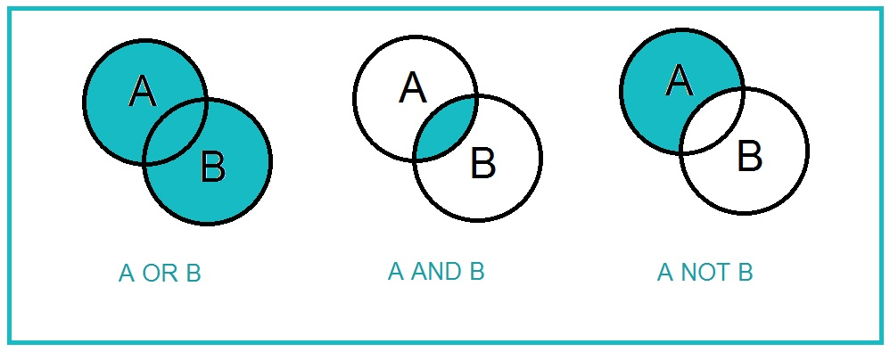

For example:

```r
############# and #################
print(10 > 5 & 5 == 5) ## Both are TRUE.
## [1] TRUE

print(10 < 5 & 5 < 2) ## Both are FALSE.
## [1] FALSE

print(10 < 5 & 5 > 2) ## First is FALSE, second is TRUE.
## [1] FALSE

## Remember, use a _leading_ ! to negative
print(10 > 5 & !(5 < 2)) ## Both are TRUE.
## [1] TRUE


############ or ##############
print(10 == 10 | 10 == 11)  ## First is TRUE, second is FALSE.
## [1] TRUE

print(10 == 10 | !(10 == 11))  ## First is TRUE, second is TRUE.
## [1] TRUE

print(10 < 4 | 10 == 11)  ## First is FALSE, second is FALSE.
## [1] FALSE


########### get crazy with it ###########
print(!(10 < 4 & 77 == 33))   # Within parantheses evaluates to FALSE, but the external ! changes things..
## [1] TRUE
```

## Data frames

*Data frames are the most fundamental unit of data analysis in R.* They are tables which consist of rows and columns, much like a *spreadsheet*. Each column is a variable which behaves as a *vector*, and each row is an observation. The type `data.frame` is itself a datatype in R, but we will (soon) be using a related datatype called a `tibble`: This is effectively a data frame within the tidyverse framework that just has a couple features that make it easier to use than a regular old data frame.

We will begin our exploration with the old trusted dataset `iris`, which comes with R. Learn about this dataset using the standard help approach of `?iris`.

### Exploring and indexing data frames

- `head()` to see the FIRST 6 rows of a data frame. Additional arguments supplied can change the number of rows.
- `tail()` to see the LAST 6 rows of a data frame. Additional arguments supplied can change the number of rows.
- `names()` to see the COLUMN NAMES of the data frame.
- `nrow()` to see how many rows are in the data frame
- `ncol()` to see how many columns are in the data frame.

Try each of these out the `iris` dataframe.

We can additionally explore *overall properties* of the data frame with two different functions: `summary()` and `str()`.

```r
## This provides summary statistics for each column (we'll learn more about these quantities soon)
summary(iris)
```

```
##   Sepal.Length    Sepal.Width     Petal.Length    Petal.Width
##  Min.   :4.300   Min.   :2.000   Min.   :1.000   Min.   :0.100
##  1st Qu.:5.100   1st Qu.:2.800   1st Qu.:1.600   1st Qu.:0.300
##  Median :5.800   Median :3.000   Median :4.350   Median :1.300
##  Mean   :5.843   Mean   :3.057   Mean   :3.758   Mean   :1.199
##  3rd Qu.:6.400   3rd Qu.:3.300   3rd Qu.:5.100   3rd Qu.:1.800
##  Max.   :7.900   Max.   :4.400   Max.   :6.900   Max.   :2.500
##        Species
##  setosa    :50
##  versicolor:50
##  virginica :50
##
##
##
```

```r
## This provides a short view of the contents of the data frame
str(iris)
```

```
## 'data.frame':    150 obs. of  5 variables:
##  $ Sepal.Length: num  5.1 4.9 4.7 4.6 5 5.4 4.6 5 4.4 4.9 ...
##  $ Sepal.Width : num  3.5 3 3.2 3.1 3.6 3.9 3.4 3.4 2.9 3.1 ...
##  $ Petal.Length: num  1.4 1.4 1.3 1.5 1.4 1.7 1.4 1.5 1.4 1.5 ...
##  $ Petal.Width : num  0.2 0.2 0.2 0.2 0.2 0.4 0.3 0.2 0.2 0.1 ...
##  $ Species     : Factor w/ 3 levels "setosa","versicolor",..: 1 1 1 1 1 1 1 1 1 1 ...
```

You’ll notice that the column `Species` is a *factor*: This is a special type of character variable that represents distinct categories known as “levels”. We have learned here that there are three levels in the `Species` column: setosa, versicolor, and virginica.

We might want to explore individual columns of the data frame more in-depth. We can *index* these columns using the dollar sign `$`:

```r
## Extract Sepal.Length as a vector
iris$Sepal.Length
```

```
##   [1] 5.1 4.9 4.7 4.6 5.0 5.4 4.6 5.0 4.4 4.9 5.4 4.8 4.8 4.3 5.8 5.7 5.4 5.1
##  [19] 5.7 5.1 5.4 5.1 4.6 5.1 4.8 5.0 5.0 5.2 5.2 4.7 4.8 5.4 5.2 5.5 4.9 5.0
##  [37] 5.5 4.9 4.4 5.1 5.0 4.5 4.4 5.0 5.1 4.8 5.1 4.6 5.3 5.0 7.0 6.4 6.9 5.5
##  [55] 6.5 5.7 6.3 4.9 6.6 5.2 5.0 5.9 6.0 6.1 5.6 6.7 5.6 5.8 6.2 5.6 5.9 6.1
##  [73] 6.3 6.1 6.4 6.6 6.8 6.7 6.0 5.7 5.5 5.5 5.8 6.0 5.4 6.0 6.7 6.3 5.6 5.5
##  [91] 5.5 6.1 5.8 5.0 5.6 5.7 5.7 6.2 5.1 5.7 6.3 5.8 7.1 6.3 6.5 7.6 4.9 7.3
## [109] 6.7 7.2 6.5 6.4 6.8 5.7 5.8 6.4 6.5 7.7 7.7 6.0 6.9 5.6 7.7 6.3 6.7 7.2
## [127] 6.2 6.1 6.4 7.2 7.4 7.9 6.4 6.3 6.1 7.7 6.3 6.4 6.0 6.9 6.7 6.9 5.8 6.8
## [145] 6.7 6.7 6.3 6.5 6.2 5.9
```

```r
## We can perform our regular array operations on columns directly, e.g:
mean(iris$Sepal.Length)
```

```
## [1] 5.843333
```

```r
## We can also achieve summary statistics for a single column directly.
## For now, you are probably comfortable with all output except "1st Qu." and "3rd Qu."
summary(iris$Sepal.Length)
```

```
##    Min. 1st Qu.  Median    Mean 3rd Qu.    Max.
##   4.300   5.100   5.800   5.843   6.400   7.900
```

```r
## Extract Species as a vector
iris$Species
```

```
##   [1] setosa     setosa     setosa     setosa     setosa     setosa
##   [7] setosa     setosa     setosa     setosa     setosa     setosa
##  [13] setosa     setosa     setosa     setosa     setosa     setosa
##  [19] setosa     setosa     setosa     setosa     setosa     setosa
##  [25] setosa     setosa     setosa     setosa     setosa     setosa
##  [31] setosa     setosa     setosa     setosa     setosa     setosa
##  [37] setosa     setosa     setosa     setosa     setosa     setosa
##  [43] setosa     setosa     setosa     setosa     setosa     setosa
##  [49] setosa     setosa     versicolor versicolor versicolor versicolor
##  [55] versicolor versicolor versicolor versicolor versicolor versicolor
##  [61] versicolor versicolor versicolor versicolor versicolor versicolor
##  [67] versicolor versicolor versicolor versicolor versicolor versicolor
##  [73] versicolor versicolor versicolor versicolor versicolor versicolor
##  [79] versicolor versicolor versicolor versicolor versicolor versicolor
##  [85] versicolor versicolor versicolor versicolor versicolor versicolor
##  [91] versicolor versicolor versicolor versicolor versicolor versicolor
##  [97] versicolor versicolor versicolor versicolor virginica  virginica
## [103] virginica  virginica  virginica  virginica  virginica  virginica
## [109] virginica  virginica  virginica  virginica  virginica  virginica
## [115] virginica  virginica  virginica  virginica  virginica  virginica
## [121] virginica  virginica  virginica  virginica  virginica  virginica
## [127] virginica  virginica  virginica  virginica  virginica  virginica
## [133] virginica  virginica  virginica  virginica  virginica  virginica
## [139] virginica  virginica  virginica  virginica  virginica  virginica
## [145] virginica  virginica  virginica  virginica  virginica  virginica
## Levels: setosa versicolor virginica
```

```r
## And view its _levels_ with the levels() function:
levels(iris$Species)
```

```
## [1] "setosa"     "versicolor" "virginica"
```

You will have more opportunities to work with data frames for this week’s assignment.

## Writing Scripts

So far, we have been directly typing code into the console and interactively examining its output. While this is tremendously valuable for a) getting comfortable with R, and b) trying out different coding strategies, *it is not a good idea long term*. Future You wants to be able to look back at your code, but if Today You types directly into the console, Future You will never know about it.

This is one of the many reasons we use **scripts** for portable programming. These are *plain text files* containing code which should ONLY be created and used in appropriate *plain text editors* - one of these exists implicitly within RStudio!  
👏 **MICROSOFT** 👏 **WORD** 👏 **IS** 👏 **NOT** 👏 **A** 👏 **TEXT EDITOR.** 👏  
👏 **PAGES** 👏 **IS** 👏 **NOT** 👏 **A** 👏 **TEXT** 👏 **EDITOR.** 👏  
👏 **GOOGLE DOCS** 👏 **IS** 👏 **NOT** 👏 **A** 👏 **TEXT** 👏 **EDITOR.** 👏  
If you would like to download a text editor separate from RStudio’s built-in option, I recommend [BBEdit](https://www.barebones.com/products/bbedit/) for Mac, [Sublime3](https://www.sublimetext.com/3) for Windows, or [Visual Studio Code](https://code.visualstudio.com/) for either platform.

### Creating and running scripts

To create an R script to edit and run from within the RStudio environment, click the White Icon with the green plus sign and select “R Script” from the dropdown.

[figure not shown]

You can now type code as you normally would in this script. Code can be executed in two ways from this script (see icons in upper-right corner of “editor” pane in the image above):

1. The **Run** button will execute code that you have *highlighted*. If nothing is highlighted, **Run** will run the code that your cursor is currently on. *Bear in mind, if your highlighted code depends on non-highlighted code, you will get an error!* A shortcut for run is cmd+Enter. It makes code very easy to run!
2. The **Source** button will execute all code in the entire script.

When writing scripts, to view *any* output, you MUST use the `print()` function. In interactive environments, simply typing a variable name will automatically reveal its value. This is NOT the case in scripts, so you must always print print print PRINT PRINT PPPPRRRRIIIINNNTTTT!!! **If you learn nothing else in this class, you will learn to PRINT. It’s *that* important**.